# Análisis multivariante

PCA y NMDS

- Introducción
- Análisis de componentes principales (PCA)
- Escalamiento multidimensional no métrico (NMDS)

## Introducción

Método estadístico que analiza simultáneamente múltiples características en cada muestra objeto de estudio.

Algunos ejemplos:

- Análisis de componentes principales
- Análisis de correspondencias
- Escalamiento multidimensional
- Análisis de correspondencias canónico
- Etc.

## Análisis de componentes principales (PCA)

El objetivo es reducir un gran número de variables perdiendo la menor cantidad de información posible.

Los nuevos componentes principales o factores serán una combinación lineal de las variables originales e independientes entre sí.

La interpretación de los factores se deducirá observando su relación con las variables iniciales.

Fases:

1. Análisis de la matriz de correlaciones. Deben existir altas correlaciones entre las variables.
2. Selección de los factores. El primer factor recoje la mayor proporción de variabilidad original, el segundo, la máxima no recogida por el primero, etc.
3. Análisis de la matriz factorial. Se representan los factores seleccionados en forma de matriz.
4. Interpretación de los factores

### Ejemplo modelización riqueza plantas exóticas a partir del clima

Modelar riqueza de especies exóticas utilizando variables climáticas.

```r
clima <- read.table("exoticas.txt", header = T, sep = "\t")
str(clima)
```

```
'data.frame':   2243 obs. of  13 variables:
 $ Alien               : int  23 32 25 46 35 89 38 46 40 4 ...
 $ Mean.Temperature    : num  6.86 7.39 5.3 7.71 7.39 ...
 $ Mean.Jan.Temperature: num  3.27 3.46 2.29 3.31 2.91 ...
 $ Rango.de.temperatura: num  4.84 6 3.98 6.46 6.53 ...
 $ PET                 : num  518 600 592 607 601 ...
 $ Min.pET             : num  8.44 13.89 12.98 12.7 11.82 ...
 $ Max.pET             : num  89.9 101.8 101.5 105.4 105.5 ...
 $ Insolation          : num  2.79 2.8 3.04 3.28 3.2 ...
 $ Growth.Season       : num  282 291 205 275 263 ...
 $ AET                 : num  459 484 434 459 451 ...
 $ Water.Defcit        : num  58.4 115.6 158 148.8 150.4 ...
 $ Precipitation       : num  1392 1605 855 959 958 ...
 $ Rainfall            : num  1392 1605 855 959 958 ...
```

Alien : variable respuesta

```r
library(corrgram)
corrgram(clima[,-1], lower.panel=panel.pts, upper.panel=panel.conf, diag.panel=panel.density)
```

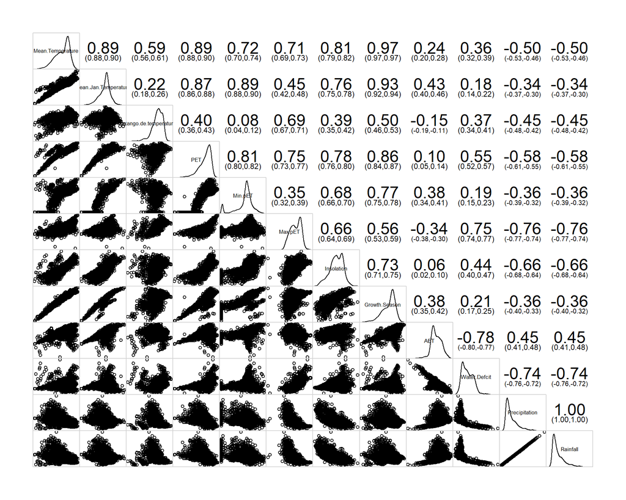

PCA para reducir la dimensionalidad y utilizar factores principales para modelar la riqueza de especies exóticas

```r
pca_1 <- prcomp(clima[,-1], scale = T)
summary(pca_1)
```

```
Importance of components:
                          PC1    PC2     PC3     PC4     PC5     PC6     PC7
Standard deviation     2.6437 1.7183 0.98154 0.71722 0.47717 0.39998 0.35721
Proportion of Variance 0.5824 0.2461 0.08028 0.04287 0.01897 0.01333 0.01063
Cumulative Proportion  0.5824 0.8285 0.90876 0.95162 0.97060 0.98393 0.99456
                           PC8     PC9    PC10    PC11     PC12
Standard deviation     0.20319 0.12922 0.08389 0.01386 0.007336
Proportion of Variance 0.00344 0.00139 0.00059 0.00002 0.000000
Cumulative Proportion  0.99800 0.99939 0.99998 1.00000 1.000000
```

```r
pca_1$rotation[,1:2]
```

```
                             PC1         PC2
Mean.Temperature      0.34852153 -0.16985773
Mean.Jan.Temperature  0.30722684 -0.31362840
Rango.de.temperatura  0.21576733  0.13711343
PET                   0.35433070 -0.09847938
Min.pET               0.27654607 -0.28400149
Max.pET               0.31976844  0.21453683
Insolation            0.33246966 -0.05442222
Growth.Season         0.32063663 -0.26539819
AET                  -0.01362093 -0.54991427
Water.Defcit          0.23318824  0.40121923
Precipitation        -0.28774698 -0.30042944
Rainfall             -0.28741001 -0.30094185
```

```r
library(factoextra)
fviz_pca_var(pca_1, col.var = "black")
```

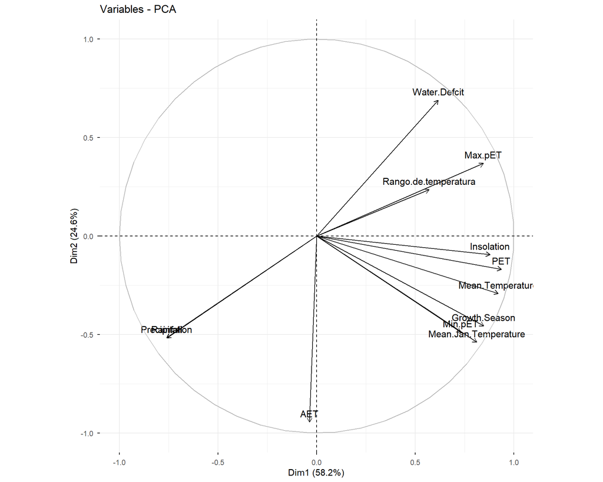

##### Ajustar modelo estadístico riqueza especies exóticas frente a los dos ejes principales

```r
clima$pca1 <- pca_1$x[,1]
clima$pca2 <- pca_1$x[, 2]
glm_exoticas1 <- glm(Alien ~ pca1 + pca2, clima, family = "poisson")
anova(glm_exoticas1)
```

```
Analysis of Deviance Table

Model: poisson, link: log

Response: Alien

Terms added sequentially (first to last)

     Df Deviance Resid. Df Resid. Dev  Pr(>Chi)
NULL                  2242     153463
pca1  1   106723      2241      46740 < 2.2e-16 ***
pca2  1      867      2240      45873 < 2.2e-16 ***
---
Signif. codes:  0 '***' 0.001 '**' 0.01 '*' 0.05 '.' 0.1 ' ' 1
```

#### Supuestos del modelo

```r
par(mfcol=c(2,2))
plot(glm_exoticas1)
```

```r
library(aods3)
gof(glm_exoticas1)
```

```
D  = 45873.44, df = 2240, P(>D) = 0
X2 = 47198.34, df = 2240, P(>X2) = 0
```

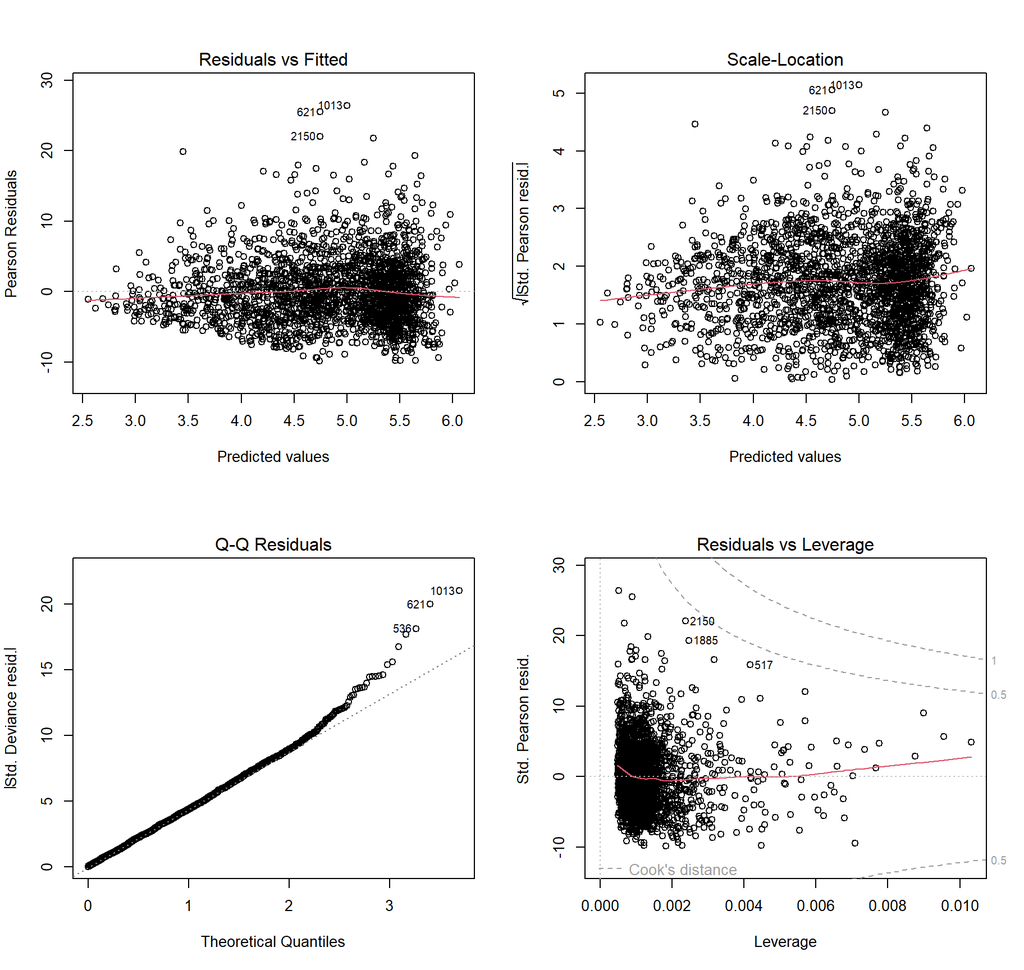

#### Modelo binomial negativo

```r
library(MASS)
glm_exoticas2 <- glm.nb(Alien ~ pca1 + pca2, clima)
par(mfcol=c(2,2))
plot(glm_exoticas2)
```

```r
gof(glm_exoticas2)
```

```
D  = 2407.635, df = 2240, P(>D) = 0.007053173
X2 = 2257.158, df = 2240, P(>X2) = 0.3952556
```

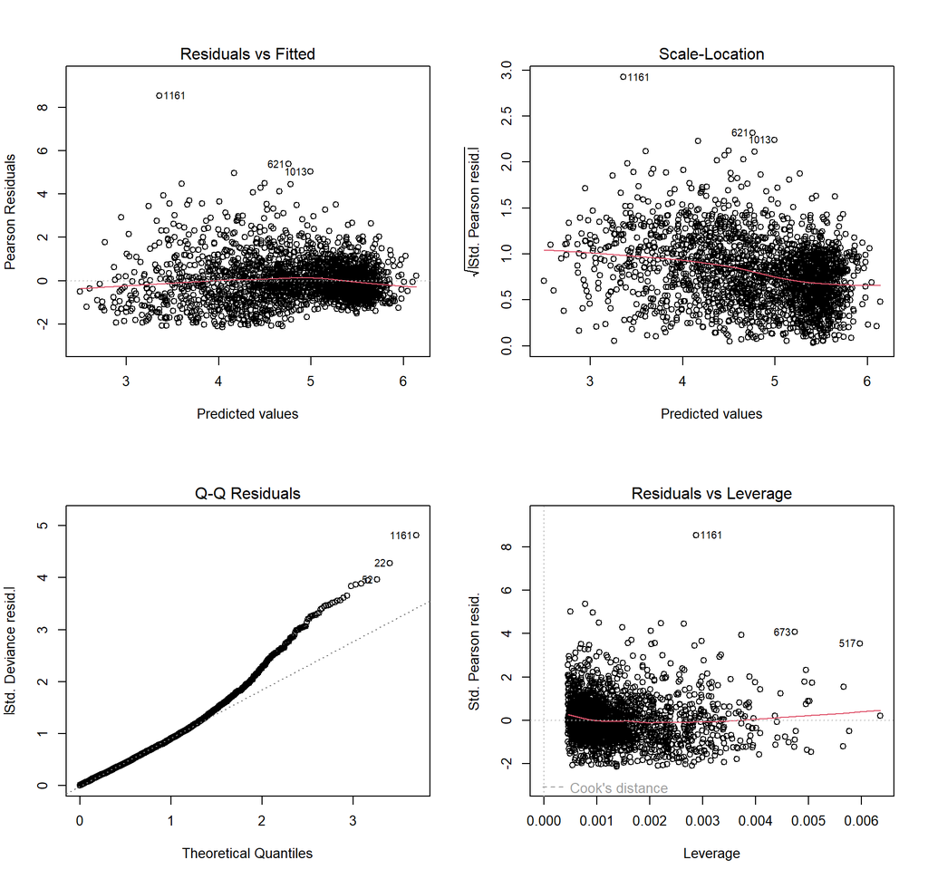

```r
anova(glm_exoticas2)
```

```
Analysis of Deviance Table

Model: Negative Binomial(5.4769), link: log

Response: Alien

Terms added sequentially (first to last)

     Df Deviance Resid. Df Resid. Dev  Pr(>Chi)
NULL                  2242     7065.4
pca1  1   4645.5      2241     2419.8 < 2.2e-16 ***
pca2  1     12.2      2240     2407.6 0.0004822 ***
---
Signif. codes:  0 '***' 0.001 '**' 0.01 '*' 0.05 '.' 0.1 ' ' 1
```

```r
library(visreg)
par(mfcol=c(1,2))
visreg(glm_exoticas2, scale="response", ylab="Riqueza de especies")
```

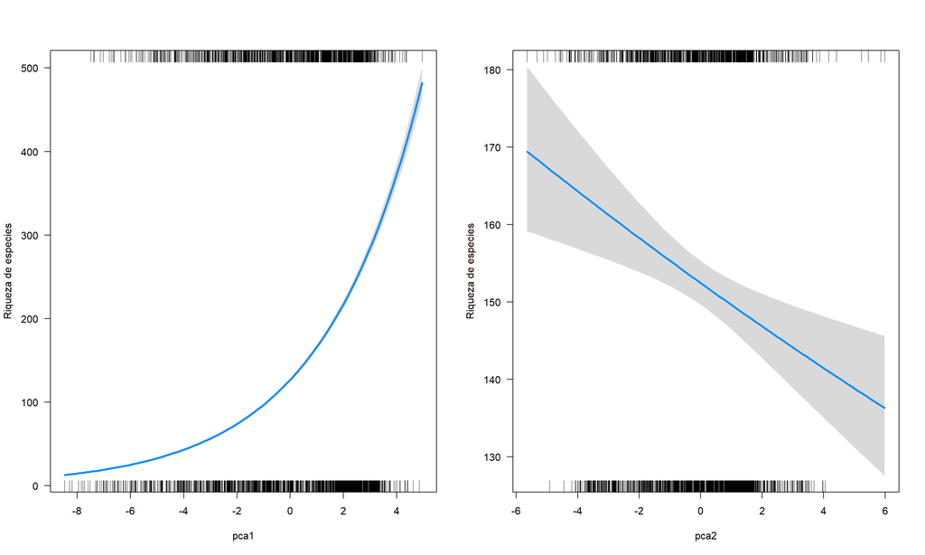

## Escalamiento multidimensional no métrico (NMDS)

Representación de las distancias existentes entre un conjunto de datos en un espacio geométrico de pocas dimensiones.

1. Cálculo matriz de disimilaridad *X* a partir de la matriz de datos.

2. Asignación de unidades muestrales a una configuración inicial aleatoria

3. Cálculo distancias otra vez en este nuevo espacio geométrico y se calcula una matriz de distancia *Y*

4. Se comparan las matrices de distancia *X* e *Y* y se miden cómo son de parecidas entre ellas (stress)

5. A partir de la configuración inicial, se reasignan las unidades muestrales para reducir las distancia con la matriz *X*

6. Repetición iterativa del proceso hasta que se consigue una solución óptima (se minimiza el stress)

## Gradiente de composición florística en bosques tropicales montanos

Investigar qué variables ambientales afectan a la composición florística de árboles en distintos tipos de bosques tropicales. Abundancia de cada especie en cada parcela.

1. Explorar visualmente cómo son de similares las parcelas muestreadas en función de la composición de especies

2. Investigar relación de esta ordenación y las variables ambientales.

```r
bio <- read.table("MANOVA-bio.txt", header=T, sep="\t")
env <- read.table("MANOVA-env.txt", header=T, sep="\t")
```

```r
library(vegan)
set.seed(0)
nmds_1 <- metaMDS(bio, distance = "bray", try = 200, trymax = 200)
```

```
Square root transformation
Wisconsin double standardization
*** Best solution repeated 31 times
```

```r
plot(nmds_1)
```

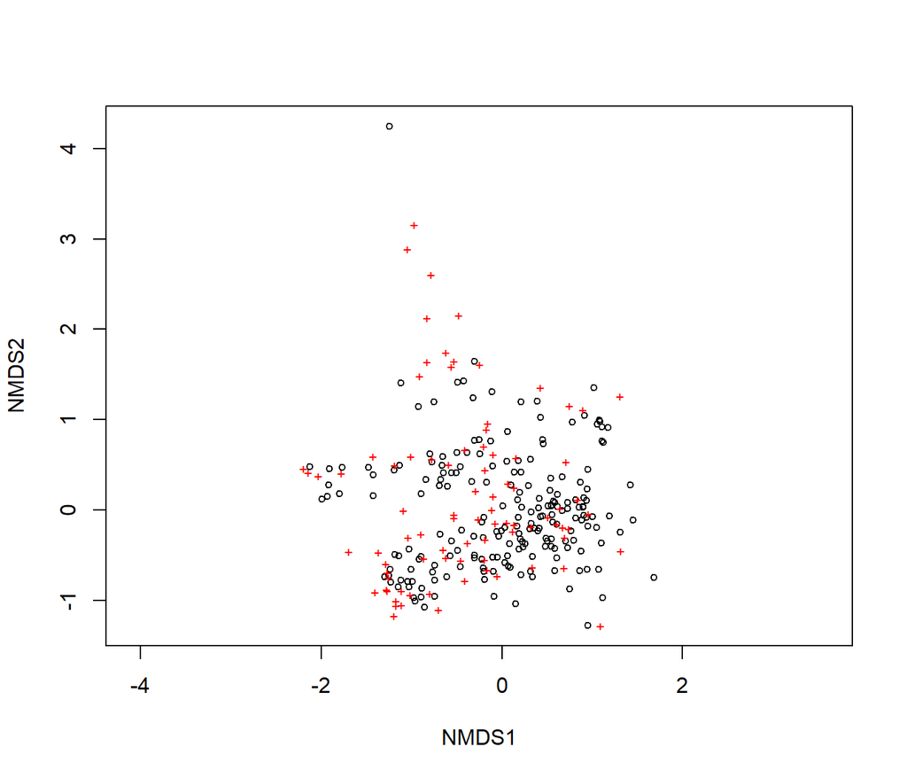

Gráfico con diferencias por tipo de bosque y relación lineal con variables

```r
coordenadas <- as.data.frame(scores(nmds_1)$sites)
coordenadas$Forest = env$Forest
envfit_res <- envfit(nmds_1, env, permutations = 999)
env_vectors <- as.data.frame(scores(envfit_res, display = "vectors"))
env_vectors$Variable <- rownames(env_vectors)

ggplot(coordenadas, aes(x = NMDS1, y = NMDS2))+
  geom_point(size = 4, aes( shape = Forest, colour = Forest)) +
# Vectores ambientales (flechas)
  geom_segment(data = env_vectors,
               aes(x = 0, xend = NMDS1, y = 0, yend = NMDS2),
               arrow = arrow(length = unit(0.3, "cm")),
               color = "black") +
  # Nombres de las variables
  geom_text(data = env_vectors,
            aes(x = NMDS1 * 1.1, y = NMDS2 * 1.1, label = Variable),
            color = "black",
            size = 4)
```

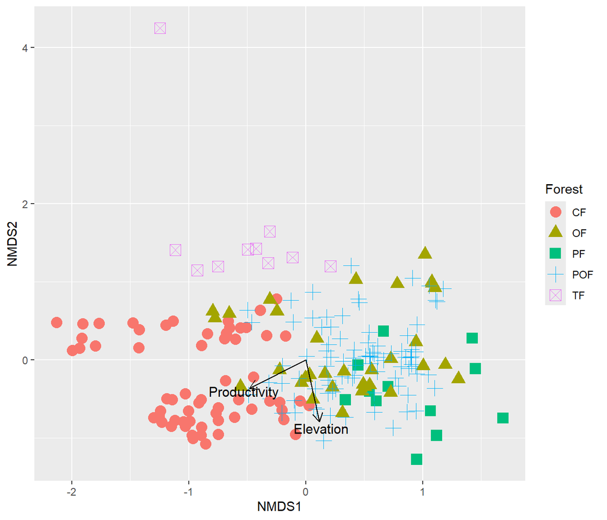